# LinkedIn Data Analysis

Jake Rozran

2021-07-29

# Total Connections Over Time

I currently have **1275** connections. My first connection was made on October 30, 2008 to [Leigh Sauter](https://www.linkedin.com/in/lhsauter). We were colleagues at The Greater Philadelphia Chamber of Commerce… well, I was an intern and she was an event coordinator.

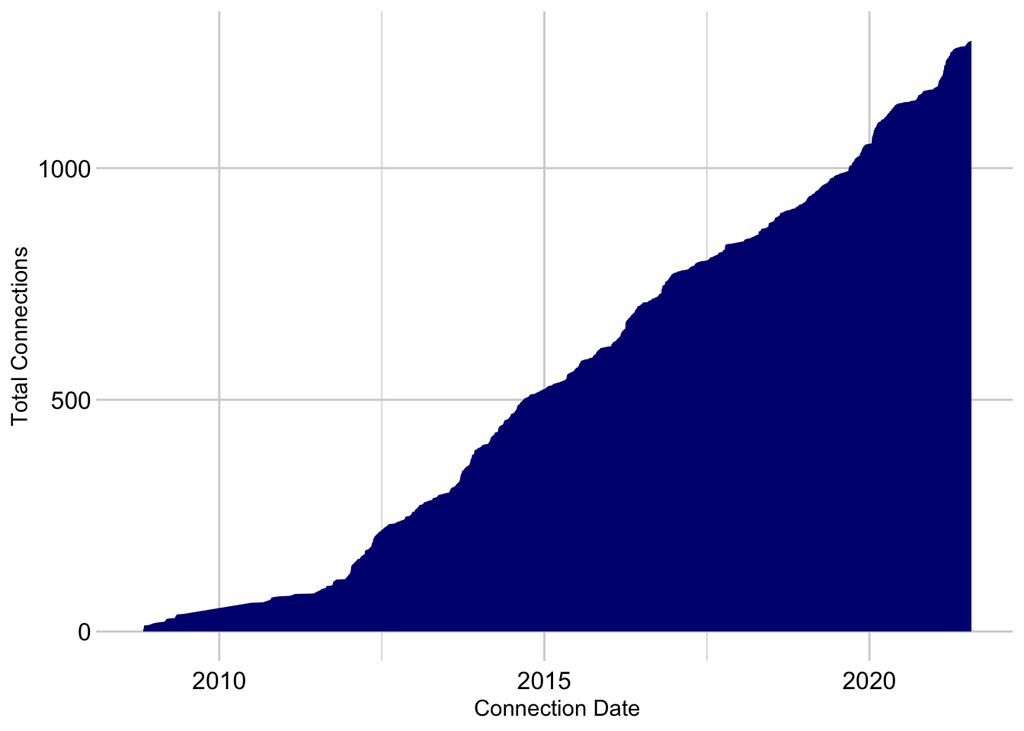

# Most Connections in a Single Day

In my most connected day, June 14, 2010 , I connected with **23** people! This was the summer after I started my first professional job and was doing some soul searching on the meaning of life and what I want to do with it.

Here is the table of awesome people who I connected with on that fateful day:

| First Name | Last Name | Company | Position | Connected On |
| --- | --- | --- | --- | --- |
| Jillian | Longpre-Smith | InstaMed, a J.P. Morgan company | Executive Director of Strategic Account Management | 2010-06-14 |
| Kristen | Simon | Berkshire Hathaway HomeServices Fox & Roach, Realtors | REALTOR | 2010-06-14 |
| Gerald | Furgione | BestCarShare Consulting | Co-Founder | 2010-06-14 |
| Maria | Quattrone | Maria Quattrone and Associates of RE/MAX @ HOME | CEO/FOUNDER | 2010-06-14 |
| Toni | Cannon | Magagna & Company | Marketing & Design Manager | 2010-06-14 |
| Kevin | Slattery, MBA | Kaiser Permanente | National Corporate Communications, Mental Health and Wellness | 2010-06-14 |
| Lawrence F. | Williams II ARM | NRM International LLC | Owner | 2010-06-14 |
| Tom | Young | Lockton Companies | Senior Vice President | 2010-06-14 |
| Julie | Novak | Lutron Electronics | Product Manager - Solutions Leader - Smart Shades | 2010-06-14 |
| Bryan | Howell | United Asphalt Company | Director of Marketing | 2010-06-14 |
| M. Erin | Lavelle | Washington Square Realty Capital | Principal | 2010-06-14 |
| Ed | Reilley | Ultra Bright Lightz | Marketing Director | 2010-06-14 |
| Jessica | Hirt | Concorde, Inc | President | 2010-06-14 |
| Stephanie | Rivadeneyra | Johnson & Johnson | Senior Brand Manager | 2010-06-14 |
| Christina | Sioutis | Ammos Glass Art | Owner, Designer | 2010-06-14 |
| Charis | Jones, MPH | U.S. Department of Homeland Security | Specialized Training Facilitator | 2010-06-14 |
| Michael | Stalbaum | CAP Index | Director of Marketing | 2010-06-14 |
| Tara | Dodsworth | Visual Sound Inc. | Account Manager | 2010-06-14 |
| Curtis | Clark | Signature Promotions & Publicity Group, CEO | CEO / Business Manager | 2010-06-14 |
| Christopher | Parker | Personal travel and relocation | Traveling | 2010-06-14 |
| Gary | Miller | TBM Consulting Group | Director | 2010-06-14 |
| Nick | Favreau | BerryDunn — Assurance, Tax and Consulting | Senior Consultant | 2010-06-14 |
| Melissa | Dietrich | Longwood Gardens | Associate Director, Membership | 2010-06-14 |

# Companies with Most Connections

Here are all the companies to which I am connected with 5 or more people:

| Company | people |
| --- | --- |
| Comcast | 177 |
| Socure | 81 |
| CivicActions | 34 |
| Booz Allen Hamilton | 27 |
| The Chamber of Commerce for Greater Philadelphia | 17 |
| NO COMPANY NAMED | 16 |
| Amazon | 10 |
| Cisco | 7 |
| Capital One | 6 |
| Johnson & Johnson | 5 |
| Prove | 5 |
| Self-employed | 5 |
| Villanova University | 5 |

# CEOs I Know

Some of my connections have quite impressive titles. **14** connections have a title of CEO!

Here’s that list:

| First Name | Last Name | Company | Position | Connected On |
| --- | --- | --- | --- | --- |
| Luke | Fretwell | ProudCity | CEO | 2021-02-23 |
| Dave | Hannes | Loved | Founder + CEO | 2020-10-15 |
| Jatin | Maniar | Singular Key | CEO & Founder | 2020-04-23 |
| Jake | Stein | Common Paper | Co-founder & CEO | 2019-05-16 |
| Edwin | Handschuh | 1Konto | Cofounder / CEO | 2019-03-20 |
| Johnny | Ayers | Socure | Founder, President & CEO | 2018-10-16 |
| Bill | Conners | Formotiv | Partner, CEO | 2018-08-15 |
| Ronald | van Loon | Ronald van Loon - Intelligent World | Principal Analyst, CEO of the Intelligent World | 2016-11-28 |
| Bob | Moore | Crossbeam | Co-Founder and CEO | 2015-07-16 |
| Nancy | Dunleavy | Dunleavy & Associates | Founder and CEO | 2013-01-06 |
| Rusty | Faircloth | W Fortis LLC | Founder and CEO | 2012-07-31 |
| Peter | Shrier | Rethinc Real Estate | Founder and CEO | 2010-10-12 |
| Maria | Quattrone | Maria Quattrone and Associates of RE/MAX @ HOME | CEO/FOUNDER | 2010-06-14 |
| Curtis | Clark | Signature Promotions & Publicity Group, CEO | CEO / Business Manager | 2010-06-14 |

# Data People I Know

Now… data is what I’m all about. Who do I know that has data in their title? **72** connections have data in their title.

Here’s that list:

| First Name | Last Name | Company | Position | Connected On |
| --- | --- | --- | --- | --- |
| Ling | Zhang | Ally | Director of Data Science - Auto Valuation | 2015-11-10 |
| Kevin T. | Hallinan | AmerisourceBergen Global Services | Senior Vice President, Global Data Services & Strategy | 2015-10-18 |
| Saleh | Alkhalifa | Amgen | Data Scientist, Team Manager — Predictive Technologies | 2019-10-21 |
| Luke | McKinstry | Azavea | Cicero Database Specialist | 2018-06-15 |
| Kiran | Muglurmath | Brighthouse Financial | Big Data Analytics Lead / Data Scientist | 2015-01-15 |
| Mike | Richman | Cadent | Data Scientist | 2018-06-13 |
| Michael | Schade | CATT Lab (Center for Advanced Transportation Technology Laboratory) | Data Visualization Engineer | 2016-03-04 |
| Brian | Lindauer | Cisco | Director of Data Science & Engineering @ Duo | 2019-05-24 |
| Nikolay | Voronchikhin | Cisco | Application Analyst - Data & Analytics Office | 2016-07-01 |
| Susana | Siman Suarez | CivicActions | Open Data Account Manager & Program Lead | 2021-02-22 |
| Tom | Adler (CSM, CSPO) | Comcast | Executive Director Wireless BI and Data Planning | 2018-07-18 |
| Sandeep | Balasundaram | Comcast | Principal Data Scientist | 2019-03-03 |
| Jim | Forsythe | Comcast | Senior Director Data Science | 2013-11-06 |
| Paul | Franceschini | Comcast | Chief Data Architect - Consultant (Oracle, Automation, Agile) | 2014-06-27 |
| Jamie | Geyer | Comcast | Sr. Manager, BI Data Operations, XFINITY Mobile | 2019-01-10 |
| Himalay | Gopu | Comcast | Director, Data Network Services | 2013-11-20 |
| Ramcharan | Kakarla | Comcast | Principal Data Scientist | 2016-12-10 |
| Chuck | Mountz, Jr | Comcast | Sr Manager, Internet Services and Data Services Engineering | 2014-12-09 |
| Kafui | Nukunya,PhD | Comcast | Director, Data Science | 2016-12-13 |
| Meet | Patel | Comcast | Lead Data Engineer | 2019-11-19 |
| Lucero | Pizano Ortiz | Comcast | Sr. Data Analyst | 2019-06-25 |
| Montreaux | Rodgers | Comcast | Sr. Data Scientist | 2019-09-25 |
| Brian | Rudowski | Comcast | Data Engineer | 2018-12-02 |
| Ghafar | Shah | Comcast | Sr. Data Analyst, Local Media Development | 2016-11-11 |
| Jim | Smith | Comcast | Sr. Engineer, Data Network Services | 2016-10-22 |
| May | Tan | Comcast | Senior Manager Enterprise Data and Analytics | 2016-03-25 |
| Eva | Xue | Comcast | Data Science Consultant | 2016-06-22 |
| Pallavi | Godavarthy | Communication Test Design Inc. (CTDI) | Sr Data Analyst | 2016-08-07 |
| Edwin | Wargo | COMPASS ACADEMY CHARTER SCHOOL | Assistant Business Administrator & Director of Data and Technology | 2016-04-28 |
| Sundar | Krishnan | CVS Health | Sr Advisor/Lead Data Scientist | 2015-04-11 |
| David | Schuler | Department of Commerce | Data Dissemination Specialist | 2021-04-16 |
| Thomas | Rayer | DLL | Datastage Developer / Agile Engineer | 2013-05-10 |
| Achyuta Nand | Jha | Expedia Group | Data Scientist II | 2018-09-20 |
| Donne | Martin | Facebook | Software Engineer, Data Privacy / Developer Infrastructure | 2016-12-07 |
| Gail | Muldoon, PhD | FCA Fiat Chrysler Automobiles | Data Scientist | 2013-09-28 |
| Ian | Snyder | GLOBO | Data Scientist | 2018-09-20 |
| Kerry | Morgenthaler | Glocomms | Data Science Recruitment Consultant | 2020-10-22 |
| Danny E. | Perez | HG Insights | Enterprise Customer Success & Data Strategy | 2018-03-26 |
| Niloy | Chakraborty | Intuit | Staff Data Engineer | 2018-08-07 |
| Benjamin | Singleton | JetBlue Airways | Director of Data Science & Analytics | 2019-05-24 |
| Katherine | Robbins | Johnson & Johnson | Data Scientist | 2017-05-09 |
| Manisha | Saha | Leading HealthCare Insurance | Data Analyst \| Sr. Business System Analyst | 2019-08-15 |
| Matthew | Pirecki | LexisNexis Risk Solutions | Senior Manager Data Science | 2019-11-07 |
| David | Zucker | McKinsey & Company | Data Strategy \| Digital Transformation \| Data Science \| Data Architecture | 2012-05-09 |
| Asim | Mathur | Netflix | Senior Data Engineer | 2015-02-20 |
| Kerri | Nunnamaker | Piano | Senior Data Analyst | 2016-04-15 |
| Benjamin | Litvinas | realtor.com | VP, Data Science & Experimentation | 2016-12-02 |
| Kalyanam | Bhargava Ram | Red Ventures | Data Engineer | 2016-06-07 |
| Dinesh | Vangumalli | Resolution Life | Data Scientist | 2019-04-13 |
| Pablo Y. | Abreu | Socure | SVP, Head of Product & Data Science | 2020-01-23 |
| Tucker | Albers | Socure | Lead Data Scientist | 2020-04-01 |
| Andres | Benvenuto, MBA | Socure | Director, Head of Data Acquisition | 2020-01-19 |
| Nick | Chapman | Socure | Data Scientist | 2018-11-30 |
| Deondre | Coston | Socure | Data Scientist | 2021-01-29 |
| Omar | Gutierrez | Socure | VP, Data Science | 2020-03-26 |
| Sunhyoung | Han | Socure | Lead Data Scientist | 2020-09-30 |
| Kate (Yurong) | Jiang | Socure | Data Scientist | 2020-01-23 |
| Luke | Osborne | Socure | Director, Data Science | 2020-09-12 |
| Parya | Roustaee | Socure | Data Scientist | 2020-02-07 |
| Chris | Rusnak | Socure | Senior Data Scientist | 2020-05-03 |
| Atsushi (Andy) | Sugino | Socure | Customer Facing Data Scientist | 2020-01-31 |
| Travis | Jones | Staples | Data Scientist; Finance | 2019-12-23 |
| Sandra | Trinh | STRATIS IoT | Data Analyst | 2020-05-15 |
| Hong | Li | T-Mobile | Digital Data Manager | 2017-06-23 |
| Radhakrishnan | G | Tata Consultancy Services | Data Science & Analytics Consultant | 2018-05-02 |
| Claire | Reynolds | The New York Times | Analyst, Data and Insights Group | 2016-04-01 |
| Alexander | Camara | Vanguard | Data Engineer | 2014-08-17 |
| Brian | Uff | Vanguard | Data & Analytics Recruiter | 2017-01-13 |
| Andres | Lebaudy | Versilium Partners | Data Science / Software / Management Consultant | 2016-05-11 |
| Michael | Posner | Villanova University | Associate Professor of Statistics and Data Science | 2015-07-08 |
| Carnell | Baugh | WSFS Bank | Data Consultant | 2015-07-16 |
| Edwin | Harvey | Your Part-Time Controller, LLC | Manager, Data Vizualization Group | 2019-08-15 |